# Supplementary Materials

The effects of urbanization and floral resources on butterfly biodiversity at stormwater ponds

Authors: Jesse D. Fortier(co-first author), Mary Ann C. Perron* (co-first author), Isabella C. Richmond, Frances R. Pick, B. Christian Schmidt, and Heather M. Kharouba

(*) Corresponding author: Mary Ann Perron, maperron@riverinstitute.ca

## Variables

**Table S1.** Variable names, acronym (used in R code), and descriptions.

| Variable | Acronym | Description |
| --- | --- | --- |
| Stormwater Pond ID | SWP | ID number provided by the City of Ottawa for each stormwater pond |
| Urbanization | anthroper | Percent cover of roads and built-up area surrounding each pond |
| Abundance | Abund/ab | Butterfly abundance that has been rarified to account for sampling effort |
| Species Richness | Richness/sr | Butterfly species richness |
| Shannon Diversity | Shannon/sh | Butterfly Shannon diversity |
| Plant species richness | nspecies | Total number of plant species richness per site |
| Native Plant Species Richness | nnative | Species richness of native plants in bloom |
| Average cover of plants in bloom | avgbloom | Average cover of plants in bloom |
| Average cover of native plants in bloom | avgnatbloom | Average cover of native plants in bloom |

## Descriptive Statistics

**Table S2.** Descriptive statistics of butterfly abundance, species richness, and Shannon diversity, and plant species richness and % bloom for all flowering plants and native flowering plants. Variable acronyms/shortforms can be found in Table S1.

| SWP | Abund | Richness | Shannon | nspecies | nnative | avgbloom | avgnatbloom |
| --- | --- | --- | --- | --- | --- | --- | --- |
| 1127 | 39 | 6.02 | 5.10 | 11 | 3 | 5.50 | 0.67 |
| 1133 | 51 | 1.00 | 1.00 | 12 | 6 | 12.82 | 10.27 |
| 1134 | 40 | 3.76 | 3.26 | 15 | 7 | 5.80 | 2.78 |
| 1204 | 69 | 7.57 | 6.53 | 20 | 8 | 9.10 | 2.82 |
| 1206 | 34 | 2.10 | 1.89 | 25 | 10 | 13.23 | 3.37 |
| 1209 | 46 | 4.16 | 3.55 | 27 | 8 | 15.00 | 6.43 |
| 1220 | 56 | 9.30 | 6.95 | 27 | 8 | 5.73 | 0.95 |
| 1227 | 27 | 6.65 | 5.49 | 24 | 5 | 9.58 | 1.20 |
| 1236 | 130 | 2.88 | 2.53 | 19 | 8 | 20.08 | 7.17 |
| 1306 | 80 | 4.09 | 3.50 | 22 | 5 | 15.98 | 7.22 |
| 1310 | 121 | 4.37 | 3.68 | 34 | 13 | 15.00 | 8.03 |
| 1314 | 18 | 2.94 | 2.29 | 18 | 3 | 5.60 | 0.92 |
| 1347 | 38 | 6.32 | 4.80 | 26 | 11 | 9.53 | 5.68 |
| 1352 | 84 | 5.21 | 4.19 | 25 | 6 | 23.25 | 2.18 |
| 1428 | 82 | 4.02 | 3.31 | 23 | 10 | 16.77 | 5.10 |
| 1501 | 107 | 4.61 | 3.89 | 23 | 14 | 10.92 | 3.23 |
| 1610 | 11 | 4.00 | 2.42 | 15 | 4 | 2.35 | 1.00 |
| 1616 | 40 | 5.69 | 4.73 | 22 | 7 | 8.13 | 4.80 |
| 1622 | 18 | 1.00 | 1.00 | 18 | 3 | 12.98 | 0.82 |
| 1809 | 76 | 6.72 | 5.50 | 24 | 10 | 16.60 | 12.68 |
| 1914 | 53 | 5.39 | 4.63 | 24 | 6 | 9.68 | 3.62 |

## Species Abundance

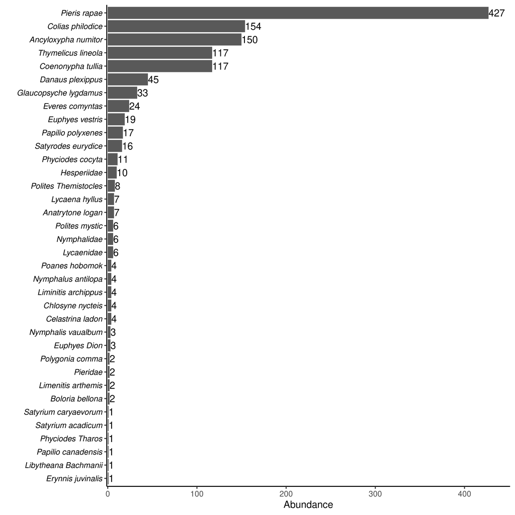

Figure S1. Raw abundance counts for each species identified and counted for this study. If a species level identification was not possible, we used genus level. If a genus level identification was not possible, we used family.

# Butterfly Abundance and Number of Native Flowering Species

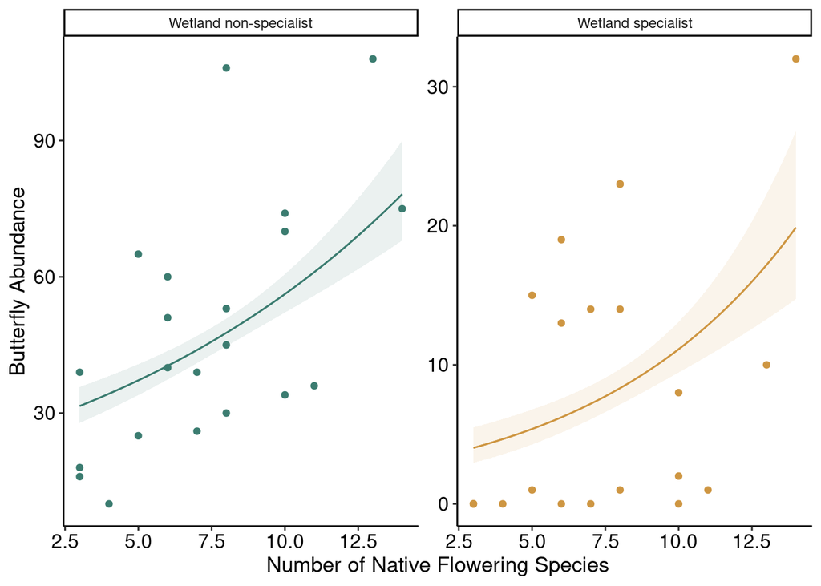

Figure S2. Native plant community models showing the the interaction between number of native flowering species and niche breadth. IRR = 1.06 +/ 1.03, p-value = 0.02, R2 = 0.69. Here we are reporting the IRR value from the interaction where the value represents the effect size of the wetland specialist group interacting with number of native flowering species and average native bloom cover compared to the effect size of the generalist group. Points are raw data from individual stormwater pond sites. Plots made using the marginaleffects package and ggplot2 (Arel-Bundock et al., 2024; Wickham et al., 2016).